Name- **Sinchana Pandiyan**

GH No- **GH1044841**

Module- **M507C Methods of Prediction**

# **Building Energy Usage Prediction Using Deep Neural Networks**

## **Section 1:- Problem Statement**

A large amount of the total energy demand and operating expenses are attributed to energy consumption in residential and commercial buildings. Ineffective energy use can result in higher costs and needless environmental damage. Organizations can plan energy consumption more effectively and put plans to increase energy efficiency into action when building energy usage is accurately predicted.

This project's goal is to forecast building energy use using historical data and environmental characteristics. The goal variable in this task is continuous energy consumption data, and it is designed as a supervised regression issue. A Multilayer Perceptron (MLP) neural network, which is ideal for modeling non-linear interactions in organized tabular data, is used to solve this issue. The suggested method can help with cost-cutting, sustainability, and well-informed decision-making in building energy management systems by precisely predicting energy consumption.

## **Section 2:- Dataset Description**

Records pertaining to building energy consumption as well as environmental and building-related characteristics are included in the dataset utilized in this study. A single observation of energy usage expressed in kilowatt-hours (kWh) is represented by each record. The dataset is appropriate for a supervised regression problem since the study's target variable, Energy_Usage (kWh), is a continuous numerical value. Both numerical and categorical values, such as temperature, humidity, building identifiers, and building characteristics, are included in the input features. Only numerical features are chosen for model development in order to maintain simplicity and robustness; timestamp information and category variables are eliminated during preprocessing. The dataset is suitable for training a neural network model and is ordered and structured.

Link:-https://www.kaggle.com/datasets/programmer3/building-energy-usage-dataset?utm_source=chatgpt.com&select=building_energy_data_extended.csv

```python
import pandas as pd
import numpy as np

from sklearn.model_selection import train_test_split
from sklearn.preprocessing import StandardScaler
from sklearn.metrics import mean_absolute_error, mean_squared_error

import tensorflow as tf
from tensorflow.keras.models import Sequential
from tensorflow.keras.layers import Dense, Dropout
```

```python
df = pd.read_csv("/content/building_energy_data_extended.csv")
df.head()
```

|  | Timestamp | Building_ID | Energy_Usage (kWh) | Temperature (°C) | Humidity (%) | Building_Type | Occupancy_Level |
| --- | --- | --- | --- | --- | --- | --- | --- |
| 0 | 2025-01-01 00:00:00 | B001 | 121.30 | -7.20 | 79.36 | Industrial | Low |
| 1 | 2025-01-01 01:00:00 | B001 | 230.76 | 12.62 | 80.37 | Industrial | High |
| 2 | 2025-01-01 02:00:00 | B001 | 187.21 | -1.33 | 37.74 | Industrial | High |
| 3 | 2025-01-01 03:00:00 | B001 | 262.23 | 0.24 | 39.97 | Industrial | High |
| 4 | 2025-01-01 04:00:00 | B001 | 472.97 | 5.44 | 89.29 | Industrial | Medium |

## **Section 3:- Exploratory Data Analysis**

Before developing a model, exploratory data analysis is carried out to provide a preliminary understanding of the dataset's structure, distribution, and quality. In order to comprehend feature ranges and variability, this analysis looks at the dataset schema and summary statistics. It also looks for missing values. A scatter plot is used to look at the link between temperature and energy consumption, and a target variable histogram is used to evaluate the distribution of energy usage. This light EDA is adequate to confirm the appropriateness of the data and guide further preprocessing choices.

```
<class 'pandas.core.frame.DataFrame'>
RangeIndex: 7200 entries, 0 to 7199
Data columns (total 7 columns):
 #   Column              Non-Null Count  Dtype
---  ------              --------------  -----
 0   Timestamp           7200 non-null   object
 1   Building_ID         7200 non-null   object
 2   Energy_Usage (kWh)  7200 non-null   float64
 3   Temperature (°C)    7200 non-null   float64
 4   Humidity (%)        7200 non-null   float64
 5   Building_Type       7200 non-null   object
 6   Occupancy_Level     7200 non-null   object
dtypes: float64(3), object(4)
memory usage: 393.9+ KB
```

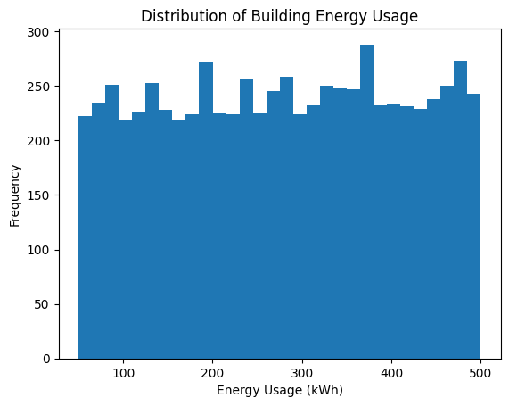

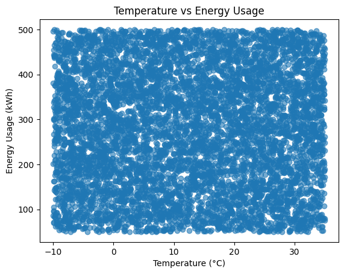

```python
import matplotlib.pyplot as plt

# Basic dataset inspection
df.info()
df.describe()
df.isnull().sum()

# Histogram of the target variable
plt.figure()
plt.hist(df["Energy_Usage (kWh)"], bins=30)
plt.xlabel("Energy Usage (kWh)")
plt.ylabel("Frequency")
plt.title("Distribution of Building Energy Usage")
plt.show()

# Scatter plot: Temperature vs Energy Usage
plt.figure()
plt.scatter(df["Temperature (°C)"], df["Energy_Usage (kWh)"], alpha=0.6)
plt.xlabel("Temperature (°C)")
plt.ylabel("Energy Usage (kWh)")
plt.title("Temperature vs Energy Usage")
plt.show()
```

## **Section 4:- Data preprocessing**

The dataset is split into training, validation, and test sets using a 70%–15%–15% ratio, as specified in the assessment guidelines, to ensure reliable model training, hyperparameter tuning, and unbiased evaluation.

```python
from sklearn.model_selection import train_test_split
from sklearn.preprocessing import StandardScaler

# Select numerical features and target variable
X = df[["Temperature (°C)", "Humidity (%)"]]
y = df["Energy_Usage (kWh)"]

# Step 1: Split out test set (15%)
X_temp, X_test, y_temp, y_test = train_test_split(
    X, y, test_size=0.15, random_state=42
)

# Step 2: Split remaining data into training (70%) and validation (15%)
X_train, X_val, y_train, y_val = train_test_split(
    X_temp, y_temp, test_size=0.1765, random_state=42
)

# Feature scaling
scaler = StandardScaler()
X_train_scaled = scaler.fit_transform(X_train)
X_val_scaled = scaler.transform(X_val)
X_test_scaled = scaler.transform(X_test)
```

## **Section 5:- Model Design & Training(MLP)**

In order to forecast building energy use, a Multilayer Perceptron (MLP) model is created and trained in this section. Regression problems using structured tabular data can benefit from the MLP's implementation as a feedforward neural network with fully connected (Dense) layers. To capture non-linear correlations between input data and the target variable, the model makes use of ReLU activation functions. Mean Absolute Error (MAE) is employed as an extra performance metric, and the Adam optimizer and mean squared error loss are used for training. Validation data is used to track performance and avoid overfitting after the model has been trained for a predetermined number of epochs.

```python
from tensorflow.keras.models import Sequential
from tensorflow.keras.layers import Dense, Dropout
from tensorflow.keras.callbacks import EarlyStopping

model = Sequential([
    Dense(64, activation='relu', input_shape=(X_train_scaled.shape[1],)),
    Dense(64, activation='relu'),
    Dense(1)
])

model.compile(
    optimizer='adam',
    loss='mse',
    metrics=['mae']
)

early_stop = EarlyStopping(
    monitor='val_loss',
    patience=5,
    restore_best_weights=True
)

history = model.fit(
    X_train_scaled,
    y_train,
    validation_data=(X_val_scaled, y_val),
    epochs=50,
    batch_size=32,
    callbacks=[early_stop],
    verbose=1
)
```

```
158/158 ━━━━━━━━━━━━━━━━━━━━ 3s 9ms/step - loss: 91986.6172 - mae: 274.1412 - val_loss: 62823.3867 - val_mae: 213.8661
158/158 ━━━━━━━━━━━━━━━━━━━━ 1s 9ms/step - loss: 42680.7031 - mae: 170.5975 - val_loss: 19075.1016 - val_mae: 117.9463
158/158 ━━━━━━━━━━━━━━━━━━━━ 2s 12ms/step - loss: 18102.0312 - mae: 114.9535 - val_loss: 18557.8828 - val_mae: 116.7897
158/158 ━━━━━━━━━━━━━━━━━━━━ 2s 12ms/step - loss: 17833.4102 - mae: 114.8120 - val_loss: 18229.8594 - val_mae: 116.0116
158/158 ━━━━━━━━━━━━━━━━━━━━ 1s 8ms/step - loss: 17649.1035 - mae: 114.2895 - val_loss: 17970.7363 - val_mae: 115.3736
158/158 ━━━━━━━━━━━━━━━━━━━━ 3s 7ms/step - loss: 17702.8730 - mae: 114.8842 - val_loss: 17778.0020 - val_mae: 114.8514
158/158 ━━━━━━━━━━━━━━━━━━━━ 1s 8ms/step - loss: 17116.5449 - mae: 112.6458 - val_loss: 17670.8242 - val_mae: 114.5728
158/158 ━━━━━━━━━━━━━━━━━━━━ 1s 7ms/step - loss: 17053.1152 - mae: 112.3428 - val_loss: 17584.4551 - val_mae: 114.3109
158/158 ━━━━━━━━━━━━━━━━━━━━ 1s 7ms/step - loss: 17398.0391 - mae: 114.2041 - val_loss: 17583.0684 - val_mae: 114.3905
158/158 ━━━━━━━━━━━━━━━━━━━━ 1s 5ms/step - loss: 16746.5156 - mae: 111.1592 - val_loss: 17447.1172 - val_mae: 113.9173
158/158 ━━━━━━━━━━━━━━━━━━━━ 1s 3ms/step - loss: 16775.3574 - mae: 111.9789 - val_loss: 17468.0820 - val_mae: 114.0191
158/158 ━━━━━━━━━━━━━━━━━━━━ 0s 3ms/step - loss: 16999.0156 - mae: 112.6291 - val_loss: 17401.1992 - val_mae: 113.8205
158/158 ━━━━━━━━━━━━━━━━━━━━ 0s 3ms/step - loss: 16806.6543 - mae: 111.9152 - val_loss: 17344.8281 - val_mae: 113.6300
158/158 ━━━━━━━━━━━━━━━━━━━━ 1s 3ms/step - loss: 16220.8291 - mae: 109.8757 - val_loss: 17352.9375 - val_mae: 113.6363
158/158 ━━━━━━━━━━━━━━━━━━━━ 1s 4ms/step - loss: 17006.6094 - mae: 112.9755 - val_loss: 17366.4766 - val_mae: 113.7856
158/158 ━━━━━━━━━━━━━━━━━━━━ 1s 4ms/step - loss: 16208.3965 - mae: 109.4539 - val_loss: 17312.4863 - val_mae: 113.5576
158/158 ━━━━━━━━━━━━━━━━━━━━ 1s 4ms/step - loss: 16633.8789 - mae: 111.2173 - val_loss: 17405.9551 - val_mae: 113.9240
158/158 ━━━━━━━━━━━━━━━━━━━━ 1s 4ms/step - loss: 16686.4609 - mae: 111.8612 - val_loss: 17256.5859 - val_mae: 113.3512
158/158 ━━━━━━━━━━━━━━━━━━━━ 0s 3ms/step - loss: 16503.0117 - mae: 111.1077 - val_loss: 17278.2188 - val_mae: 113.4706
158/158 ━━━━━━━━━━━━━━━━━━━━ 1s 3ms/step - loss: 16977.2793 - mae: 112.6780 - val_loss: 17307.3887 - val_mae: 113.5865
158/158 ━━━━━━━━━━━━━━━━━━━━ 0s 3ms/step - loss: 16809.6211 - mae: 111.6659 - val_loss: 17342.5957 - val_mae: 113.6964
158/158 ━━━━━━━━━━━━━━━━━━━━ 0s 3ms/step - loss: 16789.0840 - mae: 112.4100 - val_loss: 17272.9043 - val_mae: 113.3560
158/158 ━━━━━━━━━━━━━━━━━━━━ 0s 3ms/step - loss: 16663.0645 - mae: 111.7352 - val_loss: 17304.1504 - val_mae: 113.5032
```

```python
best_epoch = np.argmin(history.history['val_loss']) + 1
print("Best epoch:", best_epoch)
```

```
Best epoch: 18
```

## **Section 6:- Experimental Result Table**

```python
experiment_results = create_experiment_results_table()
experiment_results
```

[output not shown]

## **Section 7:- Final Model Evaluation**

```python
import numpy as np
from sklearn.metrics import mean_absolute_error, mean_squared_error

# Generate predictions
y_test_pred = model.predict(X_test_scaled)
```

```
34/34 ━━━━━━━━━━━━━━━━━━━━ 0s 3ms/step
```

```python
# Mean Absolute Error
test_mae = mean_absolute_error(y_test, y_test_pred)

# Root Mean Squared Error
test_rmse = np.sqrt(mean_squared_error(y_test, y_test_pred))

print(f"Test MAE: {test_mae:.2f}")
print(f"Test RMSE: {test_rmse:.2f}")
```

```
Test MAE: 111.80
Test RMSE: 129.57
```

```python
# Define tolerance (±5%)
tolerance = 0.05 * y_test

# Accuracy within tolerance
accuracy = np.mean(np.abs(y_test - y_test_pred.flatten()) <= tolerance) * 100

print(f"Test Accuracy (±5% tolerance): {accuracy:.2f}%")
```

```
Test Accuracy (±5% tolerance): 6.94%
```

**Actual vs Predicted Energy Usage**

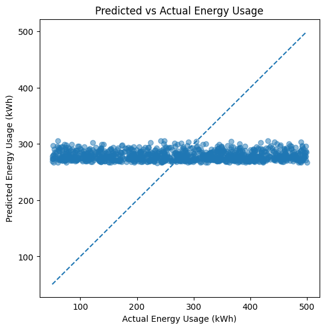

```python
import matplotlib.pyplot as plt

plt.figure(figsize=(6, 6))
plt.scatter(y_test, y_test_pred, alpha=0.5)
plt.plot([y_test.min(), y_test.max()],
         [y_test.min(), y_test.max()],
         linestyle='--')
plt.xlabel("Actual Energy Usage (kWh)")
plt.ylabel("Predicted Energy Usage (kWh)")
plt.title("Predicted vs Actual Energy Usage")
plt.show()
```